# 01. 기초수학

### 1-1 지수

#### $a$를 양의 실수$(a \neq 0)$라고 할 때, $a^x$를 다음과 같이 정의

1. $x$가 자연수일 때, $a^x$는 $a$를 $x$번 곱한다.
2. $x$가 0일 때, $a^x = 1$
3. $x$가 양의 정수 일 때, $a^{-x} = {{1} \over {a^x}}$
4. $x$가 유리수 $n / m$일 때, (단 $m, n$은 정수이며 $m > 0)$ $a^{n/m} = \sqrt[m]{a^n}$

### 1-2 지수함수

### 1-3 역함수

- **함수 $y = f(x)$의 역함수가 존재하려면, $y = f(x)$는 정의역에서 단조증가(monotone increasing)하거나 단조감소(monotone decresing)한다는 조건 필요**

### 1-4 로그함수

- 로그함수 = 지수함수 $y = a^x (x > 0, a > 0, a \neq 1)$의 역함수로, $y = log_ax$로 표기

### 1-5 자연로그의 밑 $e$

- **베르누이 (Jacob Bernoulli)는 자연로그의 밑 $e$를 극한값으로 표현** $\displaystyle\lim_{n \to \infty}{({1 + {{1} \over {n}}^n})} \approx 2.71828$

### 1-6 미분

#### 미분 가능과 미분계수

- $x$의 함수 $y = f(x)$
- $x = a$근처에서 $x$의 변화량 $\Delta x$가 한없이 0에 가까워질 때, $y$의 변화량을 $x$의 변화량으로 나눈 값, **즉 ${{\Delta y} \over {\Delta x}} = {{f(a + \Delta x) - f(a)} \over {\Delta x}}$가 어떤 일정한 값에 수렴할 때, $x = a$에서 미분 가능하다고 표현**
- **또한 이 이러한 값을 함수 $f(x)$에서의 미분계수라고 하며 $f^{'} (a)$라고 표현**
- **미분계수가 이러한 값에 수렴할 때는 함수 $f(x)$의 그래프가 $x=a$에서 직성상태가 되며 AB를 지나가는 직선 $l$은 그 직선상태와 일치**
- 이때의 직선 $l$은 $y = f(x)$그래프의 $x = a$에서의 접선이라고 볼 수 있다. **즉 점 $A(a, f(a))$를 지나고 기울기가 $f \dot(a)$인 직선의 접선이라고 볼 수 있다.**
- $y$축 위를 이동하는 점 $P$의 위치가 시간 $x$의 함수로써 $y = f(x)$로 표현될 대 ${{\Delta y} \over {\Delta x}}$를 시각 $a$와 $a + \Delta x$사이의 평균적인 빠르기, **$f^{'}(x)$를 $x=a$에서의 속도라고 정의**

#### 도함수와 기본함수의 도함수

- $f(x)$의 정의역 안에 있는 임의의 $x$의 미분계수 $f\dot(x)$를 대응시키는 함수를 함수 f(x)의 도함수라고 하며, 다음과 같이 표현

#### **$f^{'}(x) = {{dy}\over {dx}} = \displaystyle\lim_{\Delta x \to 0}{{\Delta y} \over {\Delta x}} = \displaystyle\lim_{\Delta x \to 0}{{f(a + \Delta x) - f(a)} \over {\Delta x}}$**

- 예1 $f^{'}(x) = \displaystyle\lim_{\Delta x \to 0}{{\Delta y} \over {\Delta x}} = \displaystyle\lim_{\Delta x \to 0}{{f(a + \Delta x) - f(a)} \over {\Delta x}} = \displaystyle\lim_{\Delta x \to 0}{{(x + \Delta x)^2 - (x)^2} \over {\Delta x}} = \displaystyle\lim_{\Delta x \to 0} (2x + \Delta x) = 2x$

#### 기본함수의 도함수**

- $e = \displaystyle\lim_{n \to \infty} {(1 + {1 \over n})} = 2.71828$는 오일러 상수
- $ln$은 오일러 상수 $e$를 밑으로 하는 자연로그 $(log)$. 이때 밑 $e$는 일반적으로 생략

| 함수$f(x)$ | 도함수$f^{'}(x)$ |
| --- | --- |
| c (상수) | 0 |
| $x^n$($n$은 실수) | $n$ $x^{n-1}$ |
| $e^x$ | $e^x$ |
| $a^x$ | $a^x$ $\ln a$ |
| $\ln x$ | $1 \over x$ |
| $\log_a{x}$ | ${1 \over {x \ln a}}$ |

#### 도함수의 사칙연산

- 두 함수 $f(x), g(x)$를 어떤 구간에서 미분할 수 있다면, 그 구간에서 다음과 같은 계산을 수행할 수 있다.
1. {$f(x) \pm g(x)$}$^{'}$ $= f^{'}(x) \pm g^{'}(x)$
2. {$k\;f(x)$}$^{'}$ $= k f^{'}(x)$
3. {$f(x) g(x)$}$^{'}$ $= f^{'}(x) g(x) + f(x) g^{'}(x)$
4. {$f(x) \over g(x)$}$^{'}$ $= {{f^{'}(x) g(x) - f(x)g^{'}(x)} \over {g(x)}^2}$

   특히 ${1 \over {g(x)}}^{'} = {{-g^{'}(x)} \over {g(x)}^2}$

#### 합성함수의 미분

- $y = f(u)$가 $u$에 대해 미분 가능하고 $u = g(x)$가 $x$에 대해 미분 가능하면, 함성함수 $y = f(g(x))$는 $x$에 대해 미분 가능하며 그 도함수는

  ${dy \over dx} = {dy \over du} {du \over dy}$
- 예1

$y = f(u) = u^2 = (g(x))^2 = (3x+5)^2$, ${dy \over dx} = {dy \over du} {du \over dy}$ = $2(3x+5)\;\times\;(3x+5)^{'} = 6(3x+5)$

#### 역함수의 미분

- **$y = f(x)$가 미분 가능하고 $f^{'}(x) > 0$또는 $f^{'}(x) < 0$일 때, 역함수 $x = g(y)$는 미분 가능한 함수이며,**

  ${dy \over dx} = {1 \over {dx \over dy}}$

### 1-7 실전 예제

#### 1. $log(2e^\beta + 2)$를 $\beta$에 대하여 미분

- {$log(2e^\beta + 2$}$^{'} = {{(2e^\beta + 2)^{'}} \over {2e^\beta + 2}} = {{2e^\beta} \over {2e^\beta + 2}} = {{e^\beta}\over {e^\beta + 1}}$

#### 2. 콕스모형의 가능도 함수 (& 로그 가능도 함수)

#### $L(\beta) = {e^\beta \over {(2e^\beta + 2)\;\times\;(e^\beta + 2)}}$

#### $l(\beta) = log(L(\beta)) = log(e^\beta) - log(2e^\beta + 2) - (e^\beta + 2)$

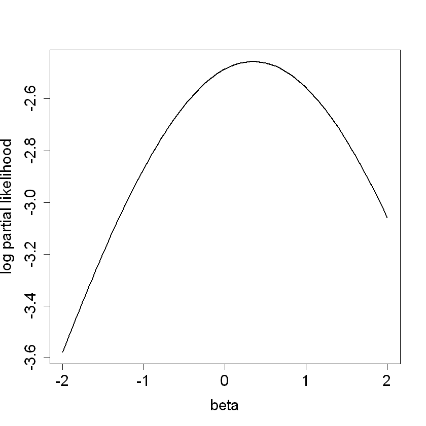

```r
pl <- function(beta) {
    psi <- exp(beta)
    result <- log(psi) - log(2 * psi + 2) - log(psi + 2)
    result
}

beta <- seq(-2, 2, length.out = 100)
plot(pl(beta) ~ beta, type = "l", xlab = "beta", ylab = "log partial likelihood",
     cex.axis = 1.5, cex.lab = 1.5, lwd = 2, col = "black")
```

#### 로그 가능도 함수를 미분한 함수 => 스코어 함수

- **스코어 함수 값은 로그 가능도 함수 그래프의 기울기**

#### $U(\beta) = l^{'}(\beta) = (\log (e^\beta) - log(2e^\beta + 2) - log(e^\beta + 2))^{'}$

$={e^\beta \over e^\beta} - {2e^\beta \over {2e^\beta + 2}} - {e^\beta \over {e^\beta + 2}}$ $= 1 - {e^\beta \over {e^\beta + 1}} - {e^\beta \over {e^\beta + 2}}$

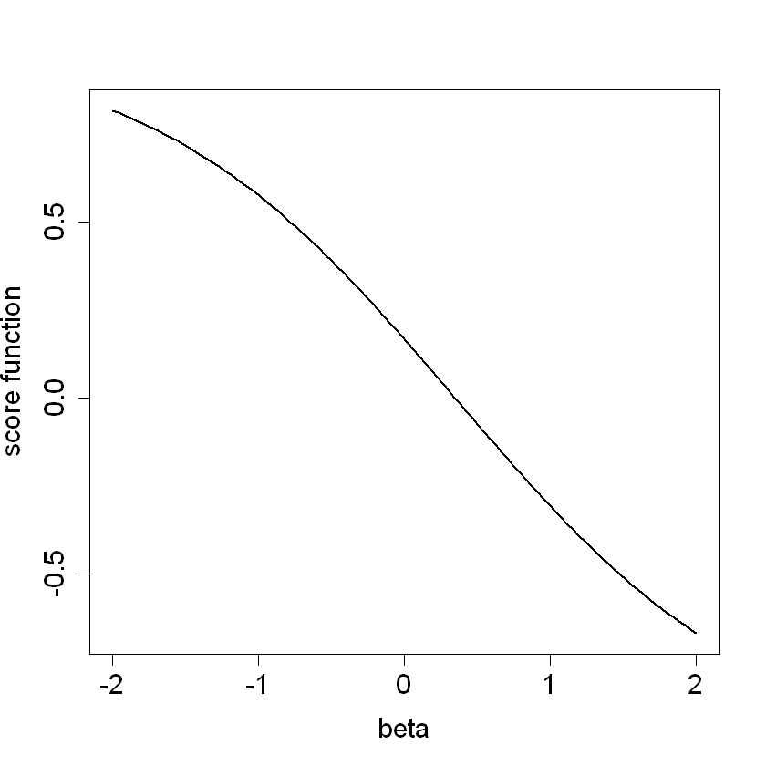

```r
scoref <- function(beta) {
    psi <- exp(beta)
    result = 1 - psi/(psi + 1) - psi/(psi + 2)
    result
}

plot(scoref(beta) ~ beta, type = "l", xlab = "beta", ylab = "score function",
     cex.axis = 1.5, cex.lab = 1.5, lwd = 2, col = "black")
```

**스코어 함수의 값이 0이되는 $\beta$의 값**

```r
result1 <- uniroot(f = scoref, interval = c(-5, 5), tol = .Machine$double.eps)
result1$root
```

0.346573590279973